```python
%load_ext nb_black
```

```python
import csv
import cv2
import matplotlib.pyplot as plt
import os
import pickle
import random
import tensorflow as tf

from skimage.filters import rank
from skimage.morphology import disk
from sklearn.utils import shuffle
from tensorflow.contrib.layers import flatten
```

# Self-Driving Car Engineer Nanodegree

## Project: Build a Traffic Sign Recognition Classifier

In this notebook, a template is provided for you to implement your functionality in stages, which is required to successfully complete this project. If additional code is required that cannot be included in the notebook, be sure that the Python code is successfully imported and included in your submission if necessary.

## Step 0: Load The Data

[Download the dataset](https://s3-us-west-1.amazonaws.com/udacity-selfdrivingcar/traffic-signs-data.zip). This is a pickled dataset in which we've already resized the images to 32x32.

```python
# Load pickled data
# Fill this in based on where you saved the training and testing data

training_file = "./traffic-signs-data/train.p"
validation_file = "./traffic-signs-data/valid.p"
testing_file = "./traffic-signs-data/test.p"

with open(training_file, mode="rb") as f:
    train = pickle.load(f)
with open(validation_file, mode="rb") as f:
    valid = pickle.load(f)
with open(testing_file, mode="rb") as f:
    test = pickle.load(f)

X_train, y_train = train["features"], train["labels"]
X_valid, y_valid = valid["features"], valid["labels"]
X_test, y_test = test["features"], test["labels"]
```

## Step 1: Dataset Summary & Exploration

The pickled data is a dictionary with 4 key/value pairs:

- `'features'` is a 4D array containing raw pixel data of the traffic sign images, (num examples, width, height, channels).
- `'labels'` is a 1D array containing the label/class id of the traffic sign. The file `signnames.csv` contains id -> name mappings for each id.
- `'sizes'` is a list containing tuples, (width, height) representing the original width and height the image.
- `'coords'` is a list containing tuples, (x1, y1, x2, y2) representing coordinates of a bounding box around the sign in the image. **THESE COORDINATES ASSUME THE ORIGINAL IMAGE. THE PICKLED DATA CONTAINS RESIZED VERSIONS (32 by 32) OF THESE IMAGES**

Complete the basic data summary below. Use python, numpy and/or pandas methods to calculate the data summary rather than hard coding the results. For example, the [pandas shape method](http://pandas.pydata.org/pandas-docs/stable/generated/pandas.DataFrame.shape.html) might be useful for calculating some of the summary results.

### Provide a Basic Summary of the Data Set Using Python, Numpy and/or Pandas

```python
print("X_train shape:", X_train.shape)
print("y_train shape:", y_train.shape)
print("\nX_valid shape:", X_valid.shape)
print("y_valid shape:", y_valid.shape)
print("\nX_test shape:", X_test.shape)
print("y_test shape:", y_test.shape)
```

```
X_train shape: (34799, 32, 32, 3)
y_train shape: (34799,)

X_valid shape: (4410, 32, 32, 3)
y_valid shape: (4410,)

X_test shape: (12630, 32, 32, 3)
y_test shape: (12630,)
```

```python
# Mapping ClassID to SignName from signnames.csv
signs = []
with open("signnames.csv", "r") as csvfile:
    signnames = csv.reader(csvfile, delimiter=",")
    next(signnames, None)
    for row in signnames:
        signs.append(row[1])

print("There are {} labels/class ids of the traffic signs.".format(len(signs)))
signs
```

```
There are 43 labels/class ids of the traffic signs.
```

```
['Speed limit (20km/h)',
 'Speed limit (30km/h)',
 'Speed limit (50km/h)',
 'Speed limit (60km/h)',
 'Speed limit (70km/h)',
 'Speed limit (80km/h)',
 'End of speed limit (80km/h)',
 'Speed limit (100km/h)',
 'Speed limit (120km/h)',
 'No passing',
 'No passing for vehicles over 3.5 metric tons',
 'Right-of-way at the next intersection',
 'Priority road',
 'Yield',
 'Stop',
 'No vehicles',
 'Vehicles over 3.5 metric tons prohibited',
 'No entry',
 'General caution',
 'Dangerous curve to the left',
 'Dangerous curve to the right',
 'Double curve',
 'Bumpy road',
 'Slippery road',
 'Road narrows on the right',
 'Road work',
 'Traffic signals',
 'Pedestrians',
 'Children crossing',
 'Bicycles crossing',
 'Beware of ice/snow',
 'Wild animals crossing',
 'End of all speed and passing limits',
 'Turn right ahead',
 'Turn left ahead',
 'Ahead only',
 'Go straight or right',
 'Go straight or left',
 'Keep right',
 'Keep left',
 'Roundabout mandatory',
 'End of no passing',
 'End of no passing by vehicles over 3.5 metric tons']
```

```python
import numpy as np

# Number of training examples
n_train = X_train.shape[0]

# Number of validation examples
n_validation = X_valid.shape[0]

# Number of testing examples.
n_test = X_test.shape[0]

# What's the shape of an traffic sign image?
image_shape = X_train[0].shape

# How many unique classes/labels there are in the dataset.
n_classes = len(np.unique(y_train))

print("Number of training examples =", n_train)
print("Number of testing examples =", n_test)
print("Image data shape =", image_shape)
print("Number of classes =", n_classes)
```

```
Number of training examples = 34799
Number of testing examples = 12630
Image data shape = (32, 32, 3)
Number of classes = 43
```

### Include an exploratory visualization of the dataset

Visualize the German Traffic Signs Dataset using the pickled file(s). This is open ended, suggestions include: plotting traffic sign images, plotting the count of each sign, etc.

The [Matplotlib](http://matplotlib.org/) [examples](http://matplotlib.org/examples/index.html) and [gallery](http://matplotlib.org/gallery.html) pages are a great resource for doing visualizations in Python.

**NOTE:** It's recommended you start with something simple first. If you wish to do more, come back to it after you've completed the rest of the sections. It can be interesting to look at the distribution of classes in the training, validation and test set. Is the distribution the same? Are there more examples of some classes than others?

```python
def show_random_images_from_dataset(features, labels, ylabel="", cmap=None):
    """
    Display random sample images from dataset.
    """
    plt.figure(figsize=(15, 15))
    for i in range(6):
        plt.subplot(1, 6, i + 1)
        index = random.randint(0, len(features))
        cmap = "gray" if len(features[index].shape) == 2 else cmap
        plt.imshow(features[index].squeeze(), cmap=cmap)
        plt.xlabel(signs[labels[index]])
        plt.ylabel(ylabel)
        plt.xticks([])
        plt.yticks([])

    plt.tight_layout()
    plt.show()
```

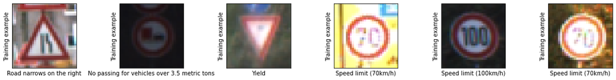

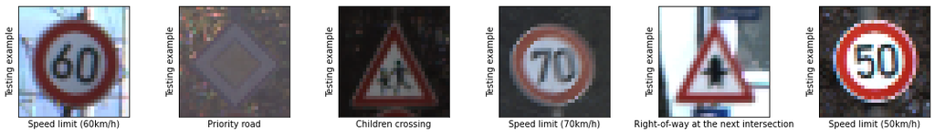

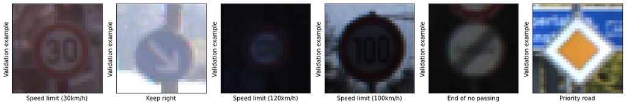

```python
# Plot random sample images from training dataset
show_random_images_from_dataset(X_train, y_train, "Training example")

# Plot random sample images from testing dataset
show_random_images_from_dataset(X_test, y_test, "Testing example")

# Plot random sample images from validation dataset
show_random_images_from_dataset(X_valid, y_valid, "Validation example")
```

```python
def plot_dataset_histogram(features, n_classes, label):
    """
    Plots a histogram which shows number of traffic sign images for each class.
    """
    hist, bins = np.histogram(features, bins=n_classes)
    width = 0.7 * (bins[1] - bins[0])
    center = (bins[:-1] + bins[1:]) / 2
    plt.bar(center, hist, align="center", width=width)
    plt.xlabel(label)
    plt.ylabel("Image count")
    plt.show()
```

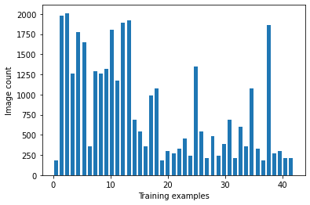

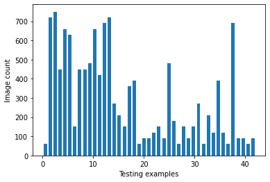

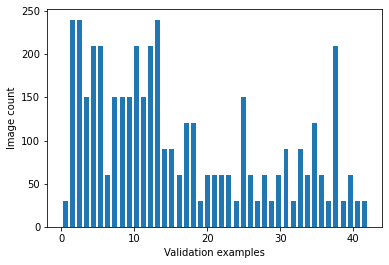

```python
# Plotting histograms of the count of each sign
plot_dataset_histogram(y_train, n_classes, "Training examples")
plot_dataset_histogram(y_test, n_classes, "Testing examples")
plot_dataset_histogram(y_valid, n_classes, "Validation examples")
```

Histograms show significant imbalance of the the number of examples per class for each data set.

Several classes in the dataset have far fewer samples than others so there is a possibility that the model will tend to be biased toward those classes with more samples. To increase accuracy of the model, we could augment existing dataset (using translation, re-scale, warp, brightness adjusstment, etc.) to increase the number of samples for the classes with fewer samples.

## Step 2: Design and Test a Model Architecture

Design and implement a deep learning model that learns to recognize traffic signs. Train and test your model on the [German Traffic Sign Dataset](http://benchmark.ini.rub.de/?section=gtsrb&subsection=dataset).

The LeNet-5 implementation shown in the classroom at the end of the CNN lesson is a solid starting point. You'll have to change the number of classes and possibly the preprocessing, but aside from that it's plug and play!

With the LeNet-5 solution from the lecture, you should expect a validation set accuracy of about 0.89. To meet specifications, the validation set accuracy will need to be at least 0.93. It is possible to get an even higher accuracy, but 0.93 is the minimum for a successful project submission.

There are various aspects to consider when thinking about this problem:

- Neural network architecture (is the network over or underfitting?)
- Play around preprocessing techniques (normalization, rgb to grayscale, etc)
- Number of examples per label (some have more than others).
- Generate fake data.

Here is an example of a [published baseline model on this problem](http://yann.lecun.com/exdb/publis/pdf/sermanet-ijcnn-11.pdf). It's not required to be familiar with the approach used in the paper but, it's good practice to try to read papers like these.

### Pre-process the Data Set (normalization, grayscale, etc.)

Minimally, the image data should be normalized so that the data has mean zero and equal variance. For image data, `(pixel - 128)/ 128` is a quick way to approximately normalize the data and can be used in this project.

Other pre-processing steps are optional. You can try different techniques to see if it improves performance.

Use the code cell (or multiple code cells, if necessary) to implement the first step of your project.

```python
def convert_to_grayscale(features):
    """
    Convert images to grayscale.
    """
    result = []
    for i in range(len(features)):
        result.append(cv2.cvtColor(features[i], cv2.COLOR_BGR2GRAY))
    return np.asarray(result)
```

- https://stackoverflow.com/a/31250215

```python
def local_histogram_equalization(features, selem):
    """
    Apply local histogram equalization to images.
    """
    result = []
    for i in range(len(features)):
        result.append(rank.equalize(features[i], selem=selem))
    return np.asarray(result)
```

- https://scikit-image.org/docs/dev/api/skimage.filters.rank.html#skimage.filters.rank.equalize

```python
def normalize(features):
    """
    Normalize images to [0,1] scale.
    """
    result = []
    for i in range(len(features)):
        result.append((features[i]) / 255)
    return np.asarray(result)
```

- https://stats.stackexchange.com/questions/185853/why-do-we-need-to-normalize-the-images-before-we-put-them-into-cnn

```python
def preprocess_dataset(features):
    """
    Apply pre-processing methods to dataset.
    """
    # convert images to grayscale
    result = convert_to_grayscale(features)
    # enhance images with low contrast
    result = local_histogram_equalization(result, selem=disk(30))
    # normalize image dataset
    result = normalize(result)

    # add one dimension at the end and return
    return result[..., None]
```

```python
# shuffle the training dataset
X_train, y_train = shuffle(X_train, y_train)
```

```python
# apply pre-processing to all data sets
X_train_processed = preprocess_dataset(X_train)
X_test_processed = preprocess_dataset(X_test)
X_valid_processed = preprocess_dataset(X_valid)
```

- https://datascience.stackexchange.com/questions/27615/should-we-apply-normalization-to-test-data-as-well

```python
print(
    "X_train mean: {:.3f}, X_train_processed mean: {:.3f}".format(
        np.mean(X_train), np.mean(X_train_processed)
    )
)
print(
    "X_test mean: {:.3f}, X_test_processed mean: {:.3f}".format(
        np.mean(X_test), np.mean(X_test_processed)
    )
)
print(
    "X_valid mean: {:.3f}, X_valid_processed mean: {:.3f}".format(
        np.mean(X_valid), np.mean(X_valid_processed)
    )
)
```

```
X_train mean: 82.678, X_train_processed mean: 0.512
X_test mean: 82.148, X_test_processed mean: 0.514
X_valid mean: 83.556, X_valid_processed mean: 0.513
```

[figure not shown]

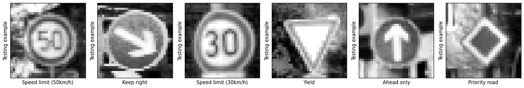

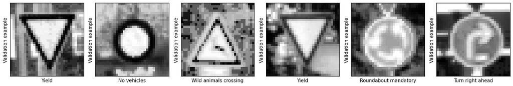

```python
# Plot random sample images from processe training dataset
show_random_images_from_dataset(
    X_train_processed, y_train, "Training example", cmap="gray"
)

# Plot random sample images from processed testing dataset
show_random_images_from_dataset(
    X_test_processed, y_test, "Testing example", cmap="gray"
)

# Plot random sample images from processed validation dataset
show_random_images_from_dataset(
    X_valid_processed, y_valid, "Validation example", cmap="gray"
)
```

Dataset pre-processing consists of:

1. converting images to grayscale
   - this is described in Sermanet and LeCun traffic sign classification article
   - using grayscale images instead of color images makes 3 times less data which reduces training time and helps obtaining better results
1. local histogram equalization
   - a lot of images from the dataset have low contrast
   - this method spreads out the most frequent intensity values in an image, resulting in enhancing low contrast images
1. normalization of images
   - normalization is a process that changes the range of pixel intensity values
   - usually the image data should be normalized so that the data has mean zero and equal variance
   - in this case, image datasets were normalized to [0,1] range, which resulted in changing datasets' means from cca 82 to cca 0.51
   - having a wider distribution in the data would make it more difficult to train
1. shuffle the the training data to increase randomness and variety in training dataset and to make model more stable

### Model Architecture

#### LeNet-5

The solution model is LeNet convolutional neural network which proved to work on many similar problems for image classification. It accepts a 32x32xC image as input, where C is the number of color channels. Since images are pre-processed to grayscale, C is 1 in this case.

The model consists of the following layers:

[output not shown]

```python
def LeNet(x):
    # Arguments used for tf.truncated_normal, randomly defines variables for the weights and biases for each layer
    mu = 0
    sigma = 0.1

    ### LAYER1 ###
    # Layer 1: Convolutional. Input = 32x32x1. Output = 28x28x6.
    # this layer has 5x5 filter with an input depth of 1, and an output depth of 6
    conv1_W = tf.Variable(
        tf.truncated_normal(shape=(5, 5, 1, 6), mean=mu, stddev=sigma)
    )
    # initialize the bias
    conv1_b = tf.Variable(tf.zeros(6))
    # use the conv2D function to convolve the filter over the images, and we add the bias at the end
    conv1 = tf.add(
        tf.nn.conv2d(x, conv1_W, strides=[1, 1, 1, 1], padding="VALID"), conv1_b
    )

    # Activation.
    # activate the output of the convolutional layer, in this case with a ReLU activation function
    conv1 = tf.nn.relu(conv1)

    # Pooling. Input = 28x28x6. Output = 14x14x6.
    # pool the output using the 2 by 2 kernel with a 2 by 2 stride, which gives us a pooling output of 14 by 14 by 6
    # the network then runs through another set of convolutional activation and pooling layers, giving an output of 5 by 5 by 16
    conv1 = tf.nn.max_pool(
        conv1, ksize=[1, 2, 2, 1], strides=[1, 2, 2, 1], padding="VALID"
    )

    ### LAYER2 ###
    # Layer 2: Convolutional. Output = 10x10x16.
    conv2_W = tf.Variable(
        tf.truncated_normal(shape=(5, 5, 6, 16), mean=mu, stddev=sigma)
    )
    conv2_b = tf.Variable(tf.zeros(16))
    conv2 = tf.add(
        tf.nn.conv2d(conv1, conv2_W, strides=[1, 1, 1, 1], padding="VALID"), conv2_b
    )

    # Activation.
    conv2 = tf.nn.relu(conv2)

    # Pooling. Input = 10x10x16. Output = 5x5x16.
    conv2 = tf.nn.max_pool(
        conv2, ksize=[1, 2, 2, 1], strides=[1, 2, 2, 1], padding="VALID"
    )

    # Flatten. Input = 5x5x16. Output = 400.
    # flatten this output into a vector; the length of the vector is 5 times 5 times 16, which equals 400
    fc0 = flatten(conv2)

    ### LAYER3 ###
    # Layer 3: Fully Connected. Input = 400. Output = 120.
    # pass this vector into a fully connected layer, with a width of 120
    fc1_W = tf.Variable(tf.truncated_normal(shape=(400, 120), mean=mu, stddev=sigma))
    fc1_b = tf.Variable(tf.zeros(120))
    fc1 = tf.add(tf.matmul(fc0, fc1_W), fc1_b)

    # Activation.
    # apply a ReLU activation to the output of this fully connected layer
    fc1 = tf.nn.relu(fc1)

    # Dropout
    fc1 = tf.nn.dropout(fc1, rate=1 - keep_prob)

    ### LAYER4 ###
    # Layer 4: Fully Connected. Input = 120. Output = 84.
    # repeat the pattern again this time with a layer width of 84
    fc2_W = tf.Variable(tf.truncated_normal(shape=(120, 84), mean=mu, stddev=sigma))
    fc2_b = tf.Variable(tf.zeros(84))
    fc2 = tf.add(tf.matmul(fc1, fc2_W), fc2_b)

    # Activation.
    fc2 = tf.nn.relu(fc2)

    # Dropout
    fc2 = tf.nn.dropout(fc2, rate=1 - keep_prob)

    ### LAYER5 ###
    # Layer 5: Fully Connected. Input = 84. Output = 43.
    # attach a fully connected output layer with a width equal to the number of classes in our label set
    # in this case,we have 43 classes; one for each traffic sign, so the with the the output layer is 43
    # these outputs are also known as our logits, which is what we return from the LeNet function
    fc3_W = tf.Variable(tf.truncated_normal(shape=(84, 43), mean=mu, stddev=sigma))
    fc3_b = tf.Variable(tf.zeros(43))
    logits = tf.add(tf.matmul(fc2, fc3_W), fc3_b)

    return logits
```

```python
# x is a placeholder for a batch of input images (batches)
# initialize the batch size to None, which allows the placeholder to later accept a batch of any size
# and we set the image dimensions to 32 by 32 by 1
x = tf.placeholder(tf.float32, (None, 32, 32, 1))

# y is a placeholder for a batch of output labels
# in this case, our labels come through with sparse variables, which just means that they're integers
# they aren't one-hot encoded yet
y = tf.placeholder(tf.int32, (None))

# one-hot encode the labels
one_hot_y = tf.one_hot(y, 43)

# a placeholder used to control the dropout rate
# the idea of a dropout is to randomly drop units (along with their connections)
# from the neural network during training to prevent overfitting
keep_prob = tf.placeholder(tf.float32)
```

- https://stackoverflow.com/questions/35545798/keep-prob-in-tensorflow-mnist-tutorial

### Train, Validate and Test the Model

A validation set can be used to assess how well the model is performing. A low accuracy on the training and validation sets imply underfitting. A high accuracy on the training set but low accuracy on the validation set implies overfitting.

```python
# the learning rate tells TensorFlow how quickly to update the network's weights
rate = 0.001

# pass the input data to the LeNet function to calculate our logits
logits = LeNet(x)

# compare those logits to the ground truth labels and calculate the cross entropy
# cross entropy is just a measure of how different the logits are from the ground truth training labels
cross_entropy = tf.nn.softmax_cross_entropy_with_logits_v2(
    labels=one_hot_y, logits=logits
)

# average the cross entropy from all of the training images
loss_operation = tf.reduce_mean(cross_entropy)

# AdamOptimizer uses the Adam algorithm to minimize the loss function similarly to what stochastic gradient descent does
# so it's a good default choice for an optimizer
optimizer = tf.train.AdamOptimizer(learning_rate=rate)

# run the minimize function on the optimizer which uses backpropagation to update the network and minimize our training loss
training_operation = optimizer.minimize(loss_operation)
```

[output not shown]

```python
EPOCHS = 30
BATCH_SIZE = 64
```

```python
# measure whether a given prediction is correct by comparing the logit prediction to the one-hot encoded ground truth label
correct_prediction = tf.equal(tf.argmax(logits, 1), tf.argmax(one_hot_y, 1))

# calculate the model's overall accuracy by averaging the individual prediction accuracies
accuracy_operation = tf.reduce_mean(tf.cast(correct_prediction, tf.float32))

# these two lines above are the entire evaluation pipeline

saver = tf.train.Saver()


# this function takes a dataset as input, sets some initial variables, and then batches the dataset and runs it through the evaluation pipeline
# the evaluate function averages the accuracy of each batch to calculate the total accuracy of the model
def evaluate(X_data, y_data):
    num_examples = len(X_data)
    total_accuracy = 0
    sess = tf.get_default_session()
    for offset in range(0, num_examples, BATCH_SIZE):
        batch_x, batch_y = (
            X_data[offset : offset + BATCH_SIZE],
            y_data[offset : offset + BATCH_SIZE],
        )
        accuracy = sess.run(
            accuracy_operation, feed_dict={x: batch_x, y: batch_y, keep_prob: 1.0}
        )
        total_accuracy += accuracy * len(batch_x)
    return total_accuracy / num_examples
```

```python
# create the TensorFlow session and initialize the variables
with tf.Session() as sess:
    sess.run(tf.global_variables_initializer())
    num_examples = len(X_train_processed)

    print("Training...")
    print()
    # train over whatever number of epochs has been set in the EPOCHS hyperparameter
    for i in range(EPOCHS):
        # at the beginning of each epoch, we shuffle our training data to ensure that our training isn't biased by the order of the images
        X_train_processed, y_train = shuffle(X_train_processed, y_train)

        # break our training data into batches and train the model on each batch
        for offset in range(0, num_examples, BATCH_SIZE):
            end = offset + BATCH_SIZE
            batch_x, batch_y = X_train_processed[offset:end], y_train[offset:end]
            sess.run(
                training_operation, feed_dict={x: batch_x, y: batch_y, keep_prob: 0.5}
            )

        # at the end of each epoch, we evaluate the model on our validation data
        validation_accuracy = evaluate(X_valid_processed, y_valid)
        print(
            "EPOCH {}: Validation Accuracy = {:.3f}".format(i + 1, validation_accuracy)
        )

    saver.save(sess, "./lenet")
    print("Model saved")
```

```
Training...

EPOCH 1: Validation Accuracy = 0.664
EPOCH 2: Validation Accuracy = 0.798
EPOCH 3: Validation Accuracy = 0.857
EPOCH 4: Validation Accuracy = 0.881
EPOCH 5: Validation Accuracy = 0.879
EPOCH 6: Validation Accuracy = 0.911
EPOCH 7: Validation Accuracy = 0.921
EPOCH 8: Validation Accuracy = 0.914
EPOCH 9: Validation Accuracy = 0.932
EPOCH 10: Validation Accuracy = 0.939
EPOCH 11: Validation Accuracy = 0.937
EPOCH 12: Validation Accuracy = 0.939
EPOCH 13: Validation Accuracy = 0.946
EPOCH 14: Validation Accuracy = 0.943
EPOCH 15: Validation Accuracy = 0.943
EPOCH 16: Validation Accuracy = 0.946
EPOCH 17: Validation Accuracy = 0.944
EPOCH 18: Validation Accuracy = 0.949
EPOCH 19: Validation Accuracy = 0.955
EPOCH 20: Validation Accuracy = 0.947
EPOCH 21: Validation Accuracy = 0.953
EPOCH 22: Validation Accuracy = 0.955
EPOCH 23: Validation Accuracy = 0.954
EPOCH 24: Validation Accuracy = 0.954
EPOCH 25: Validation Accuracy = 0.958
EPOCH 26: Validation Accuracy = 0.954
EPOCH 27: Validation Accuracy = 0.958
EPOCH 28: Validation Accuracy = 0.962
EPOCH 29: Validation Accuracy = 0.956
EPOCH 30: Validation Accuracy = 0.961
Model saved
```

```python
with tf.Session() as sess:
    sess.run(tf.global_variables_initializer())
    saver.restore(sess, tf.train.latest_checkpoint("."))

    test_accuracy = evaluate(X_test_processed, y_test)
    print("Test Accuracy = {:.3f}".format(test_accuracy))
```

```
INFO:tensorflow:Restoring parameters from ./lenet
Test Accuracy = 0.925
```

While coming upt with final solution, I combined well known implementations and I applied some tweaks to adapt the model to optimal performance for this case.

The model has **96.1** accuracy for the validation set and **92.5** accuracy for the test set, which has room for improvement, but I think it's sufficient considering that I used pre-defind data sets and I didn't perform any serious data preparation.

## Step 3: Test a Model on New Images

To give yourself more insight into how your model is working, download at least five pictures of German traffic signs from the web and use your model to predict the traffic sign type.

You may find `signnames.csv` useful as it contains mappings from the class id (integer) to the actual sign name.

### Load and Output the Images

```python
# Load and pre-process new test images
new_test_images = []
fpath = "./traffic-signs-data/new_traffic_signs_images/"
for image in os.listdir(fpath):
    img = cv2.imread(fpath + image)
    img = cv2.resize(img, (32, 32))
    img = cv2.cvtColor(img, cv2.COLOR_BGR2RGB)
    new_test_images.append(img)

new_test_images_labels = [17, 25, 8, 13, 34]
new_test_images_labels = np.asarray(new_test_images_labels)

new_test_images = np.asarray(new_test_images)
new_test_images_processed = preprocess_dataset(new_test_images)
```

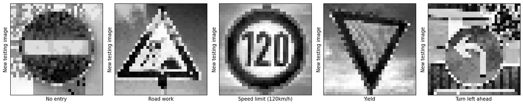

```python
plt.figure(figsize=(15, 15))
for i in range(5):
    plt.subplot(2, 5, i + 1)
    plt.imshow(new_test_images_processed[i].squeeze(), cmap="gray")
    plt.xlabel(signs[new_test_images_labels[i]])
    plt.ylabel("New testing image")
    plt.xticks([])
    plt.yticks([])

plt.tight_layout()
plt.show()
```

### Predict the Sign Type for Each Image and Analyze Performance

```python
### Run the predictions here and use the model to output the prediction for each image.
### Make sure to pre-process the images with the same pre-processing pipeline used earlier.
with tf.Session() as sess:
    sess.run(tf.global_variables_initializer())
    saver.restore(sess, tf.train.latest_checkpoint("."))

    ### Calculate the accuracy for these 5 new images.
    ### For example, if the model predicted 1 out of 5 signs correctly, it's 20% accurate on these new images.
    test_accuracy = evaluate(new_test_images_processed, new_test_images_labels)
    print("Test Accuracy = {:.3f}".format(test_accuracy))
```

```
INFO:tensorflow:Restoring parameters from ./lenet
Test Accuracy = 1.000
```

### Output Top 5 Softmax Probabilities For Each Image Found on the Web

For each of the new images, print out the model's softmax probabilities to show the **certainty** of the model's predictions (limit the output to the top 5 probabilities for each image). [`tf.nn.top_k`](https://www.tensorflow.org/versions/r0.12/api_docs/python/nn.html#top_k) could prove helpful here.

The example below demonstrates how tf.nn.top_k can be used to find the top k predictions for each image.

`tf.nn.top_k` will return the values and indices (class ids) of the top k predictions. So if k=3, for each sign, it'll return the 3 largest probabilities (out of a possible 43) and the correspoding class ids.

Take this numpy array as an example. The values in the array represent predictions. The array contains softmax probabilities for five candidate images with six possible classes. `tf.nn.top_k` is used to choose the three classes with the highest probability:

```
# (5, 6) array
a = np.array([[ 0.24879643,  0.07032244,  0.12641572,  0.34763842,  0.07893497,
         0.12789202],
       [ 0.28086119,  0.27569815,  0.08594638,  0.0178669 ,  0.18063401,
         0.15899337],
       [ 0.26076848,  0.23664738,  0.08020603,  0.07001922,  0.1134371 ,
         0.23892179],
       [ 0.11943333,  0.29198961,  0.02605103,  0.26234032,  0.1351348 ,
         0.16505091],
       [ 0.09561176,  0.34396535,  0.0643941 ,  0.16240774,  0.24206137,
         0.09155967]])
```

Running it through `sess.run(tf.nn.top_k(tf.constant(a), k=3))` produces:

```
TopKV2(values=array([[ 0.34763842,  0.24879643,  0.12789202],
       [ 0.28086119,  0.27569815,  0.18063401],
       [ 0.26076848,  0.23892179,  0.23664738],
       [ 0.29198961,  0.26234032,  0.16505091],
       [ 0.34396535,  0.24206137,  0.16240774]]), indices=array([[3, 0, 5],
       [0, 1, 4],
       [0, 5, 1],
       [1, 3, 5],
       [1, 4, 3]], dtype=int32))
```

Looking just at the first row we get `[ 0.34763842, 0.24879643, 0.12789202]`, you can confirm these are the 3 largest probabilities in `a`. You'll also notice `[3, 0, 5]` are the corresponding indices.

```
INFO:tensorflow:Restoring parameters from ./lenet
```

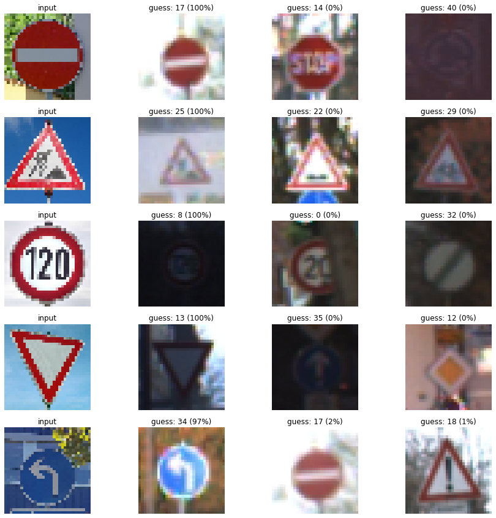

```python
### Visualize the softmax probabilities.

softmax_logits = tf.nn.softmax(logits)
top_k = tf.nn.top_k(softmax_logits, k=3)


with tf.Session() as sess:
    sess.run(tf.global_variables_initializer())
    saver.restore(sess, tf.train.latest_checkpoint("."))
    softmax_logits_calc = sess.run(
        softmax_logits, feed_dict={x: new_test_images_processed, keep_prob: 1.0}
    )
    top_k_calc = sess.run(
        top_k, feed_dict={x: new_test_images_processed, keep_prob: 1.0}
    )

    fig, axis = plt.subplots(len(new_test_images), 4, figsize=(15, 15))
    axis = axis.ravel()

    for i, image in enumerate(new_test_images):
        axis[4 * i].axis("off")
        axis[4 * i].imshow(image)
        axis[4 * i].set_title("input")

        for j in range(3):
            guess = top_k_calc[1][i][j]
            index = np.argwhere(y_valid == guess)[j]
            axis[4 * i + j + 1].axis("off")
            axis[4 * i + j + 1].imshow(X_valid[index].squeeze(), cmap="gray")
            axis[4 * i + j + 1].set_title(
                "guess: {} ({:.0f}%)".format(guess, 100 * top_k_calc[0][i][j])
            )
```

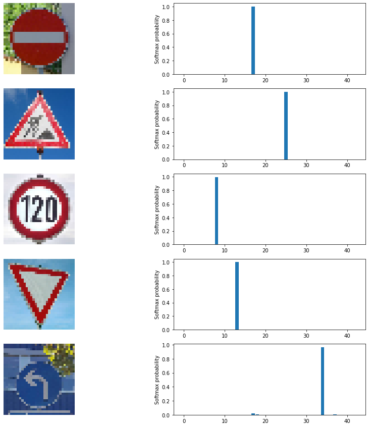

```python
### Print out the top five softmax probabilities for the predictions on the German traffic sign images found on the web.

fig, axis = plt.subplots(5, 2, figsize=(15, 15))
axis = axis.ravel()

for i in range(len(softmax_logits_calc) * 2):
    if i % 2 == 0:
        axis[i].axis("off")
        axis[i].imshow(new_test_images[i // 2])
    else:
        axis[i].bar(np.arange(n_classes), softmax_logits_calc[(i - 1) // 2])
        axis[i].set_ylabel("Softmax probability")
```

Compared to some images from the dataset, my images are quite clear and recognizable. I applied same pre-processing method on them and the model was able to correctly guess 5 of the 5 traffic signs, which gives an accuracy of **100%**.

This may be just a lucky occurrence and if we were to run it multiple times I don't think it would give constant result. This is based on test set prediction results.

## Step 4 (Optional): Visualize the Neural Network's State with Test Images

This Section is not required to complete but acts as an additional excersise for understaning the output of a neural network's weights. While neural networks can be a great learning device they are often referred to as a black box. We can understand what the weights of a neural network look like better by plotting their feature maps. After successfully training your neural network you can see what it's feature maps look like by plotting the output of the network's weight layers in response to a test stimuli image. From these plotted feature maps, it's possible to see what characteristics of an image the network finds interesting. For a sign, maybe the inner network feature maps react with high activation to the sign's boundary outline or to the contrast in the sign's painted symbol.

Provided for you below is the function code that allows you to get the visualization output of any tensorflow weight layer you want. The inputs to the function should be a stimuli image, one used during training or a new one you provided, and then the tensorflow variable name that represents the layer's state during the training process, for instance if you wanted to see what the LeNet lab's feature maps looked like for it's second convolutional layer you could enter conv2 as the tf_activation variable.

For an example of what feature map outputs look like, check out NVIDIA's results in their paper [End-to-End Deep Learning for Self-Driving Cars](https://devblogs.nvidia.com/parallelforall/deep-learning-self-driving-cars/) in the section Visualization of internal CNN State. NVIDIA was able to show that their network's inner weights had high activations to road boundary lines by comparing feature maps from an image with a clear path to one without. Try experimenting with a similar test to show that your trained network's weights are looking for interesting features, whether it's looking at differences in feature maps from images with or without a sign, or even what feature maps look like in a trained network vs a completely untrained one on the same sign image.

[figure not shown]

Your output should look something like this (above)

```python
### Visualize your network's feature maps here.
### Feel free to use as many code cells as needed.

# image_input: the test image being fed into the network to produce the feature maps
# tf_activation: should be a tf variable name used during your training procedure that represents the calculated state of a specific weight layer
# activation_min/max: can be used to view the activation contrast in more detail, by default matplot sets min and max to the actual min and max values of the output
# plt_num: used to plot out multiple different weight feature map sets on the same block, just extend the plt number for each new feature map entry


def outputFeatureMap(
    image_input, tf_activation, activation_min=-1, activation_max=-1, plt_num=1
):
    # Here make sure to preprocess your image_input in a way your network expects
    # with size, normalization, ect if needed
    # image_input =
    # Note: x should be the same name as your network's tensorflow data placeholder variable
    # If you get an error tf_activation is not defined it may be having trouble accessing the variable from inside a function
    activation = tf_activation.eval(session=sess, feed_dict={x: image_input})
    featuremaps = activation.shape[3]
    plt.figure(plt_num, figsize=(15, 15))
    for featuremap in range(featuremaps):
        plt.subplot(
            6, 8, featuremap + 1
        )  # sets the number of feature maps to show on each row and column
        plt.title("FeatureMap " + str(featuremap))  # displays the feature map number
        if activation_min != -1 & activation_max != -1:
            plt.imshow(
                activation[0, :, :, featuremap],
                interpolation="nearest",
                vmin=activation_min,
                vmax=activation_max,
                cmap="gray",
            )
        elif activation_max != -1:
            plt.imshow(
                activation[0, :, :, featuremap],
                interpolation="nearest",
                vmax=activation_max,
                cmap="gray",
            )
        elif activation_min != -1:
            plt.imshow(
                activation[0, :, :, featuremap],
                interpolation="nearest",
                vmin=activation_min,
                cmap="gray",
            )
        else:
            plt.imshow(
                activation[0, :, :, featuremap], interpolation="nearest", cmap="gray"
            )
```

```python
# N/A
```